# jagshelper-vignette

```r
library(jagshelper)
```

# jagshelper

The goal of `jagshelper` is to streamline Bayesian analysis in JAGS using the `jagsUI` package.  
Functions are provided for extracting output in a simpler form, assessing model convergence, and plotting model output. Also included is a function giving a template model in JAGS syntax with the associated `jagsUI` code.

Some of the `jagshelper` functionality is illustrated below, with steps approximately corresponding to those of a typical Bayesian analysis using JAGS.

## Model template

When starting a Bayesian analysis in JAGS from scratch, I can never remember the exact structure for doing so, and sometimes need reminding of basic JAGS model syntax.

The `skeleton()` function prints a JAGS model template to the screen, along with code to simulate a corresponding dataset.

```r
library(jagshelper)
skeleton("EXAMPLE")
```

```
#>
#> library(jagsUI)
#>
#> # specify model, which is written to a temporary file
#> EXAMPLE_jags <- tempfile()
#> cat('model {
#>   for(i in 1:n) {
#>     y[i] ~ dnorm(mu[i], tau)
#>     mu[i] <- b0 + b1*x[i] + a[grp[i]]
#>   }
#>
#>   for(j in 1:ngrp) {
#>     a[j] ~ dnorm(0, tau_a)
#>   }
#>
#>   tau <- pow(sig, -2)
#>   sig ~ dunif(0, 10)
#>   b0 ~ dnorm(0, 0.001)
#>   b1 ~ dnorm(0, 0.001)
#>
#>   tau_a <- pow(sig_a, -2)
#>   sig_a ~ dunif(0, 10)
#> }', file=EXAMPLE_jags)
#>
#>
#> # simulate data to go with the example model
#> n <- 60
#> x <- rnorm(n, sd=3)
#> grp <- sample(1:3, n, replace=T)
#> y <- rnorm(n, mean=grp-x)
#>
#> # bundle data to pass into JAGS
#> EXAMPLE_data <- list(x=x,
#>                  y=y,
#>                  n=length(x),
#>                  grp=as.numeric(as.factor(grp)),
#>                  ngrp=length(unique(grp)))
#>
#> # JAGS controls
#> niter <- 10000
#> ncores <- 3
#> # ncores <- min(10, parallel::detectCores()-1)
#>
#> {
#>   tstart <- Sys.time()
#>   print(tstart)
#>   EXAMPLE_jags_out <- jagsUI::jags(model.file=EXAMPLE_jags, data=EXAMPLE_data,
#>                              parameters.to.save=c("b0","b1","sig","a","sig_a"),
#>                              n.chains=ncores, parallel=T, n.iter=niter,
#>                              n.burnin=niter/2, n.thin=niter/2000)
#>   print(Sys.time() - tstart)
#> }
#>
#> nbyname(EXAMPLE_jags_out)
#> plotRhats(EXAMPLE_jags_out)
#> traceworstRhat(EXAMPLE_jags_out, parmfrow = c(3, 3))
```

## Output summary & Assessing convergence

### A simple model

Having run a model for the first time, it can be useful to see how many parameter nodes have been saved in total, or how many nodes exist for each named parameter. This can aid in deciding the appropriate strategy for assessing convergence: for example, whether trace plots can be feasibly assessed for all parameter nodes in the model, or just a subset.

In the example below, there are relatively few parameters saved and all trace plots can be examined.

```r
nparam(asdf_jags_out)  # how many parameters in total
```

```
#> [1] 8
```

```r
nbyname(asdf_jags_out)  # how many parameters (or dimensions) per parameter name
```

```
#> $b0
#> [1] 1
#>
#> $b1
#> [1] 1
#>
#> $sig
#> [1] 1
#>
#> $a
#> [1] 3
#>
#> $sig_a
#> [1] 1
#>
#> $deviance
#> [1] 1
```

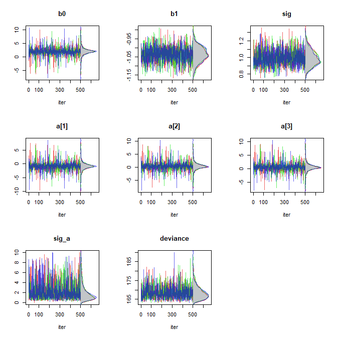

```r
tracedens_jags(asdf_jags_out, parmfrow=c(3,3))  # trace plots for all parameters
```

```r
check_Rhat(asdf_jags_out)  # proportion of Rhats below a threshold of 1.1
```

```
#>       b0       b1      sig        a    sig_a deviance
#>        1        1        1        1        1        1
```

```r
asdf_jags_out$Rhat  #  Rhat values
```

```
#> $b0
#> [1] 0.999954
#>
#> $b1
#> [1] 1.00248
#>
#> $sig
#> [1] 1.00394
#>
#> $a
#> [1] 1.0002087 0.9995671 1.0000089
#>
#> $sig_a
#> [1] 1.000986
#>
#> $deviance
#> [1] 1.001197
```

### A more complex model

In the example below, there are many more parameters saved, and it is perhaps more illustrative to examine the trace plots associated with the least- converged parameter nodes, as measured by `Rhat` value (Gelman & Rubin 1992).

```r
nparam(SS_out)  # how many parameters in total
```

```
#> [1] 334
```

```r
nbyname(SS_out)  # how many parameters (or dimensions) per parameter name
```

```
#> $trend
#> [1] 41
#>
#> $rate
#> [1] 41
#>
#> $ypp
#> [1] 41
#>
#> $fit
#> [1] 41
#>
#> $sig_eps
#> [1] 1
#>
#> $sig_xi
#> [1] 1
#>
#> $sig_omega
#> [1] 2
#>
#> $cycle
#> [1] 41
#>
#> $cycle_s
#> [1] 41  2
#>
#> $ar1
#> [1] 41
#>
#> $phi
#> [1] 1
#>
#> $deviance
#> [1] 1
```

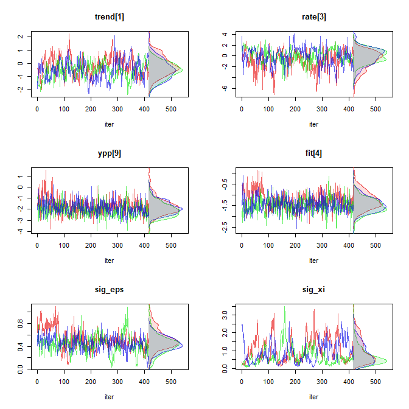

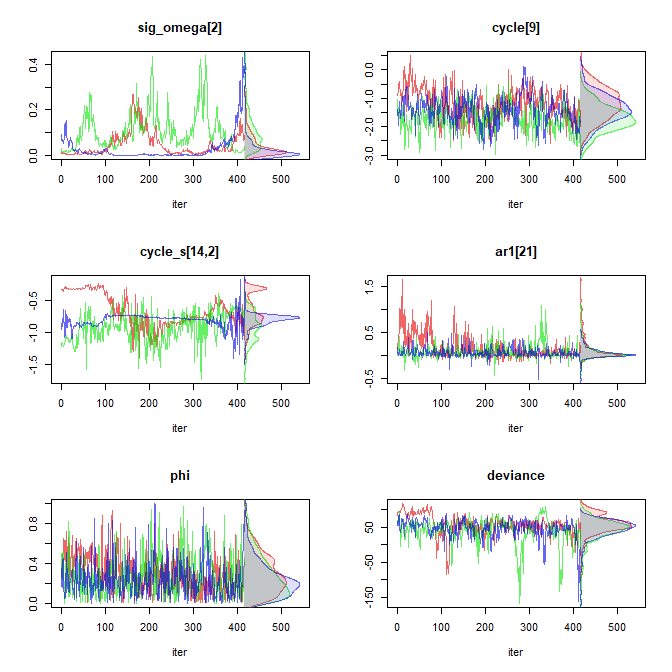

```r
traceworstRhat(SS_out, parmfrow=c(3,2))  # trace plots for least-converged nodes
```

```r
check_Rhat(SS_out)  # proportion of Rhats below a threshold of 1.1
```

```
#>     trend      rate       ypp       fit   sig_eps    sig_xi sig_omega     cycle
#> 1.0000000 1.0000000 1.0000000 0.9268293 1.0000000 1.0000000 0.5000000 0.8780488
#>   cycle_s       ar1       phi  deviance
#> 0.5121951 0.7692308 1.0000000 1.0000000
```

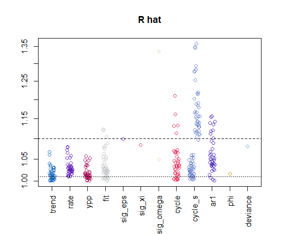

```r
plotRhats(SS_out)  # plotting Rhat values
```

### Additional functionality

- The function `check_neff()` behaves very similarly to `check_Rhat()`, but makes comparisons based on `n.eff` (a crude measure of effective sample size) rather than Gelman-Rubin convergence diagnostic `Rhat`.
- The functions `traceworstRhat()` and `check_Rhat()` both contain an optional `n.eff=` argument. When set to `TRUE`, the functions will compare or plot based on the value of `n.eff` rather than `Rhat`.
- The function `tracedens_jags()` is likely to be the most useful and concise trace plot version. However, if only line trace plots or by-chain kernel density plots are desired (rather than both), older versions `trace_jags()` and `chaindens_jags()` are preserved.
- The function `qq_postpred()` produces a quantile-quantile plot from the posterior predictive distributions associated with a vector of data. This can be visually interpreted in a similar manner to a traditional Q-Q plot, with an appropriately-specified model producing a plot that falls along the x=y line. While not intended as an omnibus posterior predictive check, this plot might be useful in detecting overparameterization, poor convergence, or a mis-specified error model. It should be noted that this function depends on the existence of a matrix of posterior predictive samples, which is up to the user. This can be specified within JAGS, or via appropriate simulation from the posterior samples.
- The function `ts_postpred()` provides a similar utility in detecting possible overparameterization, as well as features in a dataset with respect to the corresponding posterior predictive distributions. It produces an envelope plot of the centered posterior predictive distribution, defined as the difference between the posterior predictive and the posterior predictive median. The centered time series is overlayed, similarly defined as the difference between the time series and the posterior predictive median.

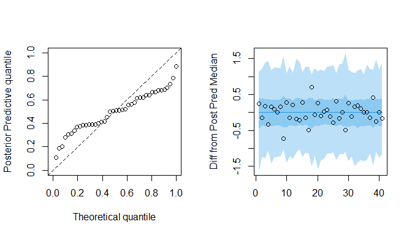

  ```r
  old_parmfrow <- par("mfrow")   # storing previous graphics state
  par(mfrow=c(1, 2))
  qq_postpred(ypp=SS_out, p="ypp", y=SS_data$y)
  ts_postpred(ypp=SS_out, p="ypp", y=SS_data$y)
  ```

  ```r
  par(mfrow=old_parmfrow)        # restoring previous graphics state
  ```

- The function `plot_postpred()` is a wrapper that produces a sequence of plots: first, an `envelope()` plot of the posterior predictive distribution overlayed with raw data values, then a call to `ts_postpred()` giving a time series of the posterior predictive residual distribution overlayed with the data residuals, then a plot of the residual standard deviation calculated over a moving window. By default, these three plots are given with respect to the data sequence, then with respect to the data supplied for x, then with respect to fitted values.
- The function `kfold()` provides automated k-fold or leave-one-out cross validation for a specified component of a JAGS data object, for a specified JAGS model.

JAGS is run internally `k` times (or alternately, the size of the dataset), withholding each of `k` “folds” of the input data and drawing posterior predictive samples corresponding to the withheld data, which can then be compared to the input data to assess model predictive power.

Global measures of predictive power are provided in output: Root Mean Square (Prediction) Error and Mean Absolute (Prediction) Error. However, it is likely that these measures will not be meaningful by themselves; rather, as a metric for scoring a set of candidate models.

- The function `pairstrace_jags()` gives methods for plotting two-dimensional trace plots, scatter plots, or contour plots, in which each possible pairing of parameter nodes are plotted with respect to one another. In addition to convergence, this may provide a graphical check for correlation between parameter nodes, or problematic posterior surface shapes. An example is shown below.

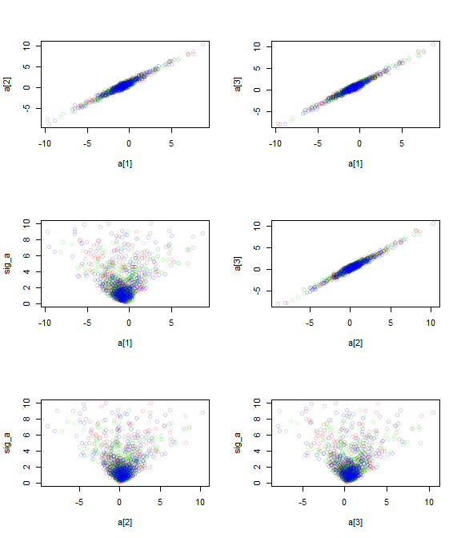

```r
pairstrace_jags(asdf_jags_out, p=c("a","sig_a"), points=TRUE, parmfrow=c(3,2))
```

- The functions `cor_jags()` and `plotcor_jags()` respectively return and plot correlation matrices of all or a subset of parameters, which may be useful in directly assessing correlation between parameters. In the case of multiple nodes per parameter (as in a vector or array of nodes), the full collection of nodes per parameter name is given one axis tick. This is intended to reduce graphical clutter as well as giving greater visual weight to single parameters. An example is given below.

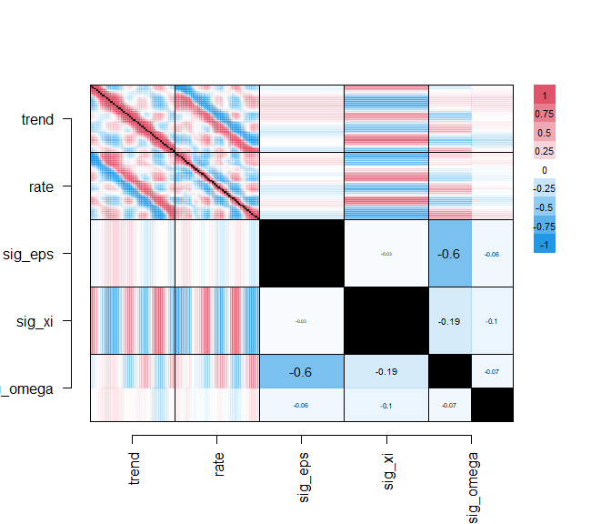

```r
plotcor_jags(SS_out, p=c("trend","rate","sig"))
```

## Extracting output as data.frame

The `jags_df()` function extracts all posterior samples from an output object returned by `jagsUI::jags()` as a `data.frame`, which may be preferable for some users.

```r
out_df <- jags_df(asdf_jags_out)
str(out_df)
```

```
#> 'data.frame':    1500 obs. of  8 variables:
#>  $ b0      : num  -1.27 -1.54 1.43 1.88 1.35 ...
#>  $ b1      : num  -0.976 -1.075 -1.031 -1.035 -1.048 ...
#>  $ sig     : num  0.945 1.213 1.063 1.179 1.12 ...
#>  $ a[1]    : num  1.7815 3.0941 -0.2099 -0.7276 0.0799 ...
#>  $ a[2]    : num  3.397 4.155 0.687 0.47 0.682 ...
#>  $ a[3]    : num  3.747 4.351 1.18 0.349 1.247 ...
#>  $ sig_a   : num  6.538 5.047 0.82 0.526 0.708 ...
#>  $ deviance: num  171 174 165 171 169 ...
```

### Additional functionality

- Functions for trace plots and by-chain kernel density are available with `trace_df()` and `chaindens_df()`, respectively, if model output is only saved in `data.frame` form. Note that both functions contain an additional `nline=` argument corresponding to the number of MCMC chains that were run.
- Functions `trace_line()` and `chaindens_line()` are also included for completeness, which take a single vector of MCMC iterations (associated with a single parameter) as input. Note that both functions contain an additional `nline=` argument corresponding to the number of MCMC chains that were run.

## Plotting a matrix associated with a vector of parameter nodes

### A single matrix

The `caterpillar()` and `envelope()` functions plot output associated with a vector of parameter nodes. This is often expressed as a two-dimensional matrix or `data.frame`, with a column for each parameter node and a row for each MCMC iteration. Both `caterpillar()` and `envelope()` were originally written to accept such `data.frame`s as inputs, but now also accept a `jagsUI` output object and parameter name.

It is anticipated that `caterpillar()` could be used for effect sizes associated with a categorical variable, in which plotting order may or may not matter. However, interval bars may also be plotted with respect to a quantitative variable as supplied by a numeric vector input.  
`caterpillar()` plots may be oriented vertically (default) or horizontal (shown below).

By contrast, `envelope()` is intended for a matrix associated with a sequence of parameter nodes, such as in a time series.

For a simpler case, `plotdens()` produces a kernel density plot of a single parameter node, or overlays multiple parameter nodes from a list. Alternately (shown below) it overlays kernel density plots of a vector of parameter nodes.

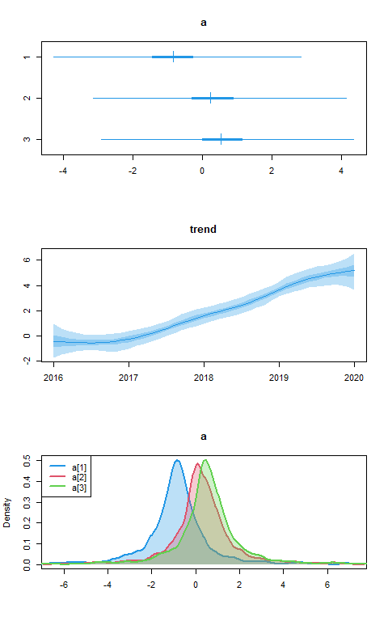

```r
old_parmfrow <- par("mfrow")  # storing old graphics state
par(mfrow=c(3,1))
caterpillar(asdf_jags_out, "a", horizontal=TRUE)
envelope(SS_out, "trend", x=SS_data$x)
plotdens(asdf_jags_out, "a")
```

```r
par(mfrow=old_parmfrow)  # resetting graphics state
```

### Multiple matrices or multiple models

It may be appropriate to make by-element comparisons of multiple such matrices, perhaps between multiple candidate models.

Function `comparecat()` produces interleaved caterpillar plots for a list of `jagsUI` output objects and an optional list of parameters, plotting parameters common to a set of models adjacent to one another. The example below uses the same output object three times, but will show functionality.

Function `comparedens()` behaves similarly, but produces left- and right-facing kernel density plots for TWO `jagsUI` output objects and an optional list of parameters. The example below uses the same output object twice, but will show functionality.

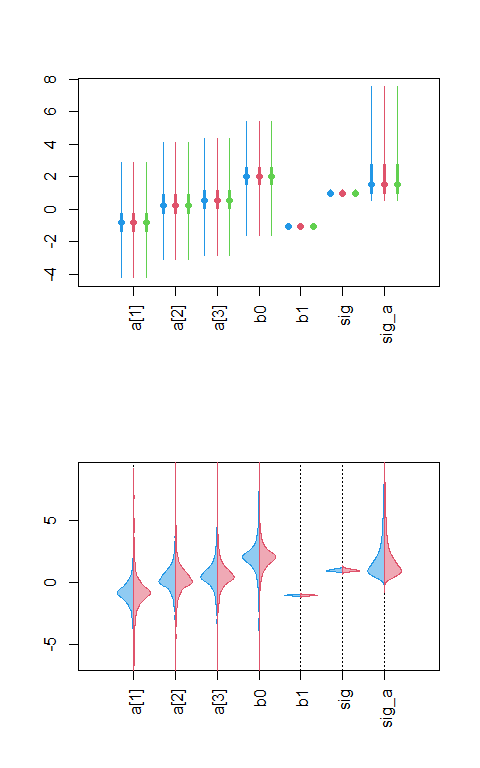

```r
old_parmfrow <- par("mfrow")  # storing old graphics state
par(mfrow=c(2,1))
comparecat(x=list(asdf_jags_out, asdf_jags_out, asdf_jags_out),
           p=c("a","b","sig"))
comparedens(x1=asdf_jags_out, x2=asdf_jags_out, p=c("a","b","sig"))
```

```r
par(mfrow=old_parmfrow)  # resetting graphics state
```

Function `overlayenvelope()` will automatically overlay multiple `envelope()` plots, and may be used with a variety of input structures:

- A `list()` of 2-dimensional posterior `data.frame`s or matrices
- A 3-dimensional `array`, in which multiple 2-dimensional posterior matrices are joined along the third dimension
- A `list()` of `jagsUI` output objects, plus a parameter name
- A single `jagsUI` output objects, plus a vector of parameter names

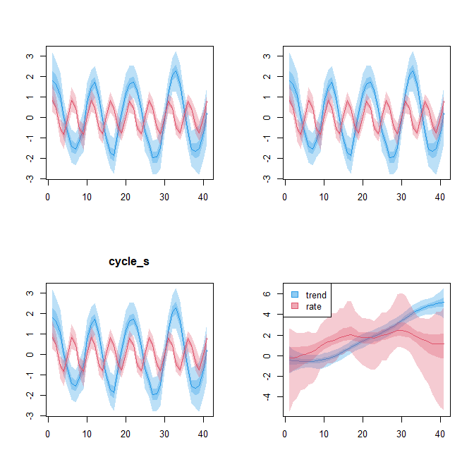

```r
par(mfrow=c(2,2))

## usage with list of input data.frames
overlayenvelope(df=list(SS_out$sims.list$cycle_s[,,1],
                            SS_out$sims.list$cycle_s[,,2]))

## usage with a 3-d input array
overlayenvelope(df=SS_out$sims.list$cycle_s)

## usage with a jagsUI output object and parameter name (2-d parameter)
overlayenvelope(df=SS_out, p="cycle_s")

## usage with a single jagsUI output object and multiple parameters
overlayenvelope(df=SS_out, p=c("trend","rate"))
```

Function `crossplot()` plots corresponding pairs of parameter densities on the X- and Y-axes. Three plotting methods are provided, that may be overlayed if desired:

- If drawcross == TRUE, caterpillar-like plots will be produced, with quantile intervals in the x- and y- directions.
- If drawx == TRUE, caterpillar-like plots will be produced, but rotated along the standardized principal component axes. This may be useful to draw if correlation is present.
- If drawblob == TRUE, smoothed polygons will be produced, each containing approximately ci= x100% of the associated MCMC samples.

This function may be used with vectors or matrices of MCMC samples, or with a `jagsUI` object and a vector of parameter names.

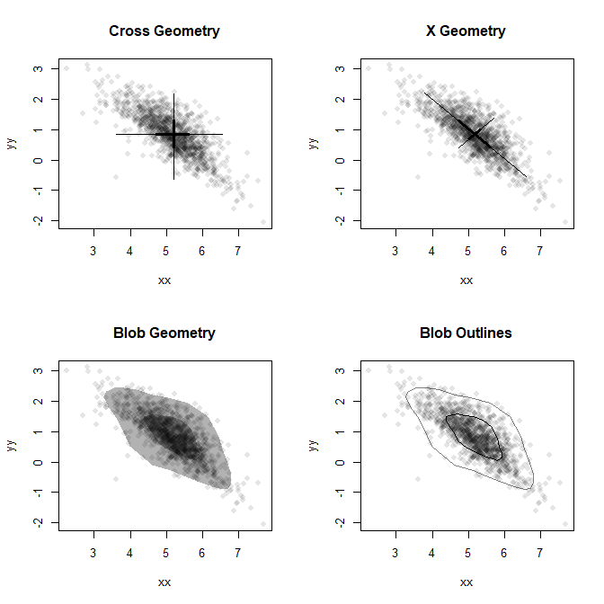

```r
## Usage with single vectors (or data.frames or 2d matrices)
xx <- SS_out$sims.list$trend[,41]
yy <- SS_out$sims.list$cycle[,41]

## Showing possible geometries
par(mfrow = c(2, 2))
plot(xx, yy, col=adjustcolor(1, alpha.f=.1), pch=16, main="Cross Geometry")
crossplot(xx, yy, add=TRUE, col=1)
plot(xx, yy, col=adjustcolor(1, alpha.f=.1), pch=16, main="X Geometry")
crossplot(xx, yy, add=TRUE, col=1,
          drawcross=FALSE, drawx=TRUE)
plot(xx, yy, col=adjustcolor(1, alpha.f=.1), pch=16, main="Blob Geometry")
crossplot(xx, yy, add=TRUE, col=1,
          drawcross=FALSE, drawblob=TRUE)
plot(xx, yy, col=adjustcolor(1, alpha.f=.1), pch=16, main="Blob Outlines")
crossplot(xx, yy, add=TRUE, col=1,
          drawcross=FALSE, drawblob=TRUE, outline=TRUE)
```

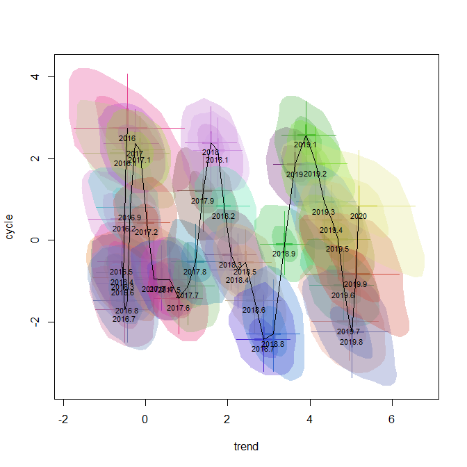

```r
## Usage with jagsUI object and parameter names, plus addl functionality
par(mfrow = c(1, 1))
crossplot(SS_out, p=c("trend","cycle"),
          labels=SS_data$x, labelpos=1, link=TRUE, drawblob=TRUE,
          col="random")
```

### Comparison between priors and posteriors

Function `comparepriors()` is a wrapper for `comparedens()`, and plots side-by-side kernel densities of all parameters with names ending in `"_prior"`, along with the respective posterior densities. It should be noted that additional parameters must be included in the JAGS model to provide samples of the prior distributions, as is shown in the example below.

```r
...
sig ~ dunif(0, 10)   # this is the parameter that is used elsewhere in the model
sig_prior ~ dunif(0, 10)  # this is only used to give samples of the prior
...
```

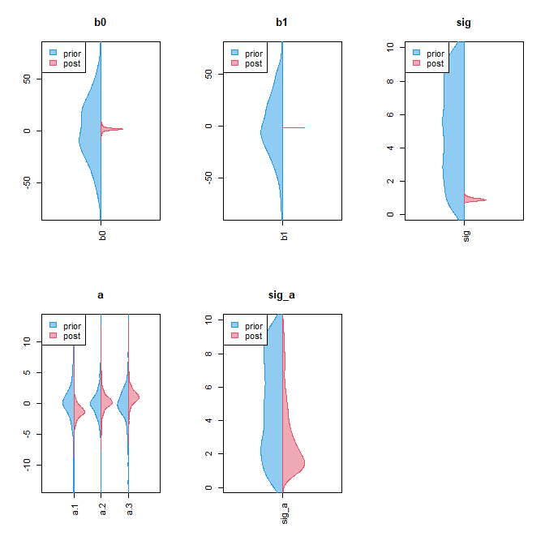

```r
comparepriors(asdf_prior_jags_out, parmfrow=c(2,3))
```